# Mental Health in the Tech Industry

[figure not shown]

## DISCLAIMER: When viewing this notebook on Github

> Open the notebook in jupyterlab for optimal experience.

Some charts/diagrams/features are not visible in github.

This impacts all:

- plotly plots
- folium maps
- embedded images
- and all other dynamic content

This is [standard and well-known behaviour](https://blog.jupyter.org/rendering-notebooks-on-github-f7ac8736d686).

While some workarounds could be possible, there are no fixes for all of the issues.

- Plotly customization [requires installing external tools](https://github.com/plotly/plotly.py/issues/931), but doesn't fix the other issues
- Standard workarounds ([nbviewer](http://nbviewer.jupyter.org/)) do not work because the github repo is private.

### Workaround

> Open the notebook in jupyterlab for optimal experience.

# Context

We work in a mid-size IT help desk consultancy and our CEO has tasked us with helping the People&Talent team implement a company-wide survey around mental health for everyone, but with a special focus on tech roles.

## Our Goal

We have been provided a dataset that contains mental health survey results across various years in order to get insights into how we can make a better survey and gather more insights from our employees.

We are looking at:

- industry trends
- patterns in the survey
- insights around mental health in tech
- and we ultimately, want to find ways to make better surveys in our company

# Loading data

💭 If you are running this locally, remember to `pip install -r requirements.txt` before proceeding

```python
%reload_ext autoreload
%autoreload 1

from IPython.display import display, Markdown
import matplotlib.pyplot as plt
import matplotlib.patches as patches

import numpy as np
import pandas as pd
import seaborn as sns
import bisect

from random import random, seed
import sqlite3 as lite

from utils import handy_utils as util
from utils import pandas_auto_types as auto_pandas
from utils import auto_kaggle
from utils import chart_utils as charts
import mh_utils

%aimport utils.handy_utils
%aimport utils.auto_kaggle
%aimport utils.pandas_auto_types
%aimport utils.chart_utils
%aimport mh_utils
```

Let's enable auto-format for our code

```python
import lab_black

%reload_ext lab_black
util.patch_nb_black()
```

```python
seed(100)
pd.options.display.max_rows = 100
pd.options.display.max_colwidth = 40

util.check("done")
```

```
yes! ✅
```

```python
dataset = "anth7310/mental-health-in-the-tech-industry"
db_filename = "mental_health.sqlite"
auto_kaggle.download_dataset(dataset, db_filename)
```

```
Kaggle API 1.5.12 - login as 'edualmas'
No need to re-download dataset [anth7310/mental-health-in-the-tech-industry]
File [dataset/mental_health.sqlite] exists locally!
```

# Initial Inspection

Let's take a look at the database objects to get our bearings

```python
conn = lite.connect("dataset/" + db_filename)
```

```python
all_tables = "SELECT name FROM sqlite_schema WHERE type ='table' "
excluding_system_tables = " name NOT LIKE 'sqlite_%'"
table_list = pd.read_sql_query(f"{all_tables} AND {excluding_system_tables}", conn)
tables = table_list.to_dict()["name"].values()
tables
```

```
dict_values(['Answer', 'Question', 'Survey'])
```

It seems there are 3 tables. Let's peek and see what type of data they contain

We will get a random sample of rows so we have a more rounded feeling of their contents

```python
for table in tables:
    df = pd.read_sql_query(f"SELECT * FROM {table} ORDER BY RANDOM() LIMIT 10", conn)
    display(Markdown("\n## The `" + table + "` table"))
    display(df)
    display(Markdown("___"))
```

The `Answer` table

|  | AnswerText | SurveyID | UserID | QuestionID |
| --- | --- | --- | --- | --- |
| 0 | Rarely | 2016 | 2487 | 48 |
| 1 | Some did | 2017 | 3413 | 23 |
| 2 | White | 2018 | 3724 | 89 |
| 3 | Making employees comfortable bringin... | 2019 | 3982 | 86 |
| 4 | 1 | 2017 | 3340 | 70 |
| 5 | No | 2014 | 1246 | 12 |
| 6 | Don't know | 2014 | 1000 | 97 |
| 7 | -1 | 2018 | 3568 | 59 |
| 8 | No | 2019 | 3908 | 83 |
| 9 | No, because it doesn't matter | 2017 | 2974 | 52 |

The `Question` table

|  | questiontext | questionid |
| --- | --- | --- |
| 0 | Did you feel that your previous empl... | 111 |
| 1 | Have you had a mental health disorde... | 32 |
| 2 | How easy is it for you to take medic... | 97 |
| 3 | Describe the conversation your cowor... | 63 |
| 4 | Have you ever sought treatment for a... | 7 |
| 5 | Do you feel that your employer takes... | 91 |
| 6 | Describe the circumstances of the ba... | 82 |
| 7 | Did your previous employers ever for... | 25 |
| 8 | Was your employer primarily a tech c... | 68 |
| 9 | If you have a mental health conditio... | 92 |

The `Survey` table

|  | SurveyID | Description |
| --- | --- | --- |
| 0 | 2016 | mental health survey for 2016 |
| 1 | 2019 | mental health survey for 2019 |
| 2 | 2018 | mental health survey for 2018 |
| 3 | 2014 | mental health survey for 2014 |
| 4 | 2017 | mental health survey for 2017 |

## Table summary

- **Survey**: we can forget about this table, forever, and never look back. None of the data it contains will be missed. This is the sharknado of all database tables.
- **Question**: This table can be used to understand the meaning of the recorded answers. This will require substantial manual work to identify valuable questions that can helps us separate the wheat from the chaff.
- **Answer**: once we have selected the valuable questions, we will spend most of our time working with this table.
  - This table contains everything, all squashed into one column, without regard for our mental wellbeing. May Codd have mercy for our souls

```python
# let's create a small utility that we will reuse extensively
def sql_peek(
    md_title: str, sql: str, limit: int = 100, print_sql: bool = False
) -> pd.DataFrame:
    """
    renders a small table view of the provided query, with a nice markdown formatted header
    """
    query = f"{sql} LIMIT {limit};"
    df_ = pd.read_sql_query(query, conn)
    display(Markdown(md_title))
    if print_sql:
        display(Markdown("`" + query + "`"))
    display(df_.head(limit))
    display(Markdown("___"))
```

```python
unique_questions = """SELECT COUNT(DISTINCT QuestionID) FROM Answer"""
sql_peek("### Unique Questions", unique_questions)

questions_per_year = """
    SELECT SurveyID, COUNT(DISTINCT QuestionID)
    FROM Answer
    GROUP BY SurveyID"""

sql_peek("### Questions per year", questions_per_year)

unique_questions = """SELECT COUNT(*) FROM Answer"""
sql_peek("### Total Answers", unique_questions)
```

Unique Questions

|  | COUNT(DISTINCT QuestionID) |
| --- | --- |
| 0 | 105 |

Questions per year

|  | SurveyID | COUNT(DISTINCT QuestionID) |
| --- | --- | --- |
| 0 | 2014 | 26 |
| 1 | 2016 | 60 |
| 2 | 2017 | 76 |
| 3 | 2018 | 76 |
| 4 | 2019 | 76 |

Total Answers

|  | COUNT(*) |
| --- | --- |
| 0 | 236898 |

## Checking for duplications

We believe that there are no repeated answers for a given year-user-question tuple. i.e. that users can only vote once per survey.

Let's just double check it, to be extra sure.

```python
q_find_duplicates_answers = """
 SELECT SurveyID, QuestionID, UserID, COUNT(*) AS responses
 FROM Answer
 GROUP BY SurveyID, QuestionID, UserID
 HAVING responses > 1
 ORDER BY responses DESC
"""
sql_peek("### Finding duplicate answers", q_find_duplicates_answers, 10)
```

Finding duplicate answers

|  | SurveyID | QuestionID | UserID | responses |
| --- | --- | --- | --- | --- |
| 0 | 2016 | 117 | 1838 | 10 |
| 1 | 2016 | 115 | 2625 | 9 |
| 2 | 2016 | 117 | 1359 | 9 |
| 3 | 2016 | 117 | 2068 | 9 |
| 4 | 2016 | 115 | 1435 | 8 |
| 5 | 2016 | 115 | 2441 | 8 |
| 6 | 2016 | 116 | 2252 | 8 |
| 7 | 2016 | 117 | 1783 | 8 |
| 8 | 2016 | 117 | 1959 | 8 |
| 9 | 2016 | 117 | 2372 | 8 |

Alright.. that's pretty bad. User `1838` has entered 10 distinct responses to the same question...

Let's dig a bit deeper. Let's see how big is this. We want to see how many cases are there (in terms of surveys and questions)

```python
q_duplication_spread = f"""
SELECT SurveyID, QuestionID, COUNT(*)
FROM ({q_find_duplicates_answers})
GROUP BY SurveyID, QuestionID
ORDER BY COUNT(*) DESC
"""
sql_peek("### Finding duplicate spread", q_duplication_spread)
```

Finding duplicate spread

|  | SurveyID | QuestionID | COUNT(*) |
| --- | --- | --- | --- |
| 0 | 2016 | 117 | 616 |
| 1 | 2016 | 115 | 367 |
| 2 | 2016 | 116 | 207 |

```python
q_inspecting_3_cases_of_duplication = f"""
SELECT *
FROM Answer
WHERE (SurveyID, QuestionID, UserID) IN
    (
     (2016, 115, 2441),
     (2016, 116, 2252),
     (2016, 117, 1783)
    )
"""

sql_peek("### Inspecting 3 cases of duplication", q_inspecting_3_cases_of_duplication)
```

Inspecting 3 cases of duplication

|  | AnswerText | SurveyID | UserID | QuestionID |
| --- | --- | --- | --- | --- |
| 0 | Anxiety Disorder (Generalized, Socia... | 2016 | 2441 | 115 |
| 1 | Mood Disorder (Depression, Bipolar D... | 2016 | 2441 | 115 |
| 2 | Eating Disorder (Anorexia, Bulimia, ... | 2016 | 2441 | 115 |
| 3 | Attention Deficit Hyperactivity Diso... | 2016 | 2441 | 115 |
| 4 | Personality Disorder (Borderline, An... | 2016 | 2441 | 115 |
| 5 | Obsessive-Compulsive Disorder | 2016 | 2441 | 115 |
| 6 | Post-traumatic Stress Disorder | 2016 | 2441 | 115 |
| 7 | Stress Response Syndromes | 2016 | 2441 | 115 |
| 8 | Anxiety Disorder (Generalized, Socia... | 2016 | 2252 | 116 |
| 9 | Mood Disorder (Depression, Bipolar D... | 2016 | 2252 | 116 |
| 10 | Psychotic Disorder (Schizophrenia, S... | 2016 | 2252 | 116 |
| 11 | Eating Disorder (Anorexia, Bulimia, ... | 2016 | 2252 | 116 |
| 12 | Attention Deficit Hyperactivity Diso... | 2016 | 2252 | 116 |
| 13 | Obsessive-Compulsive Disorder | 2016 | 2252 | 116 |
| 14 | Post-traumatic Stress Disorder | 2016 | 2252 | 116 |
| 15 | Stress Response Syndromes | 2016 | 2252 | 116 |
| 16 | Other | 2016 | 1783 | 117 |
| 17 | One-person shop | 2016 | 1783 | 117 |
| 18 | Back-end Developer | 2016 | 1783 | 117 |
| 19 | Sales | 2016 | 1783 | 117 |
| 20 | Support | 2016 | 1783 | 117 |
| 21 | DevOps/SysAdmin | 2016 | 1783 | 117 |
| 22 | Dev Evangelist/Advocate | 2016 | 1783 | 117 |
| 23 | Supervisor/Team Lead | 2016 | 1783 | 117 |

It seems these cases of duplication:

- only affect 3 specific questions in 2016
- seem to be related to a question that allowed multiple choice answers
- they make sense from a business perspective

However, due to their configuration being discontinued in the following years, it will difficult our cross-year analysis, since we won't have anything to compare equal-to-equal across years.

Cleaning approach:

- We will replace their answers for 2016 with their values from 2017 to allow cross-year comparisons.

### Keeping track of offenders

```python
df_duplicated_answers = pd.read_sql_query(q_find_duplicates_answers, conn)
df_duplicated_answers_idx = df_duplicated_answers[["SurveyID", "QuestionID", "UserID"]]
df_duplicated_answers.head()
```

|  | SurveyID | QuestionID | UserID | responses |
| --- | --- | --- | --- | --- |
| 0 | 2016 | 117 | 1838 | 10 |
| 1 | 2016 | 115 | 2625 | 9 |
| 2 | 2016 | 117 | 1359 | 9 |
| 3 | 2016 | 117 | 2068 | 9 |
| 4 | 2016 | 115 | 1435 | 8 |

Let's move forward

## A Deeper dive into the survey data

With over +230k answers spread across +100 unique questions, we will need to be careful when selecting the most optimal subset of questions to analyze.

We would like to have a small sample of the types of questions that this database contains, and a few of the answers provided. It would also be ideal if we could calculate or guess how is the spread of answers for each question (was it a yes/no question? was it multiple choice? was it free text?). As a bonus, we would also like to have the info for each of the years. Maybe a question was "yes/no" the first year, and got changed to a multiple choice the second year.

We can write a *little tiny* SQL query that will do all of these things, and maybe a bit more! Let's make a list of the features needed:

**REQUIREMENTS**

1. IT MUST show a sample of the answers collected for each of the questions
2. IT MUST NOT include invalid answers (in this database '-1' seems to be a special value indicating `N/A`)
3. IT MUST include the question prompt as text
4. IT MUST distinguish across years (`question 3` in year `2014` is not the same as `question 3` in year `2015`).
   - Just because they reused the same text prompt, does not mean that the options/dropdown lists they gave to respondents were the same.
5. IT SHOULD be able to infer the type of question it is, based on the spread of the answers (binary? multiple choice? free text?...)
6. IT COULD sort answers so we can easily find them, padding with 0s would be great
7. IT COULD print results in a format that's easy to read (tabulated? pivoted to columns?.. )

## Sampling the answers

```python
q_questions_with_sample_answers = """
   WITH padded_answers AS (select AnswerText,
                                   SurveyID,
                                   UserID,
                                   substr('000' || QuestionID, -3, 3) AS QuestionID
                            from Answer),
         valid_answers AS (SELECT AnswerText,
                                  UserID,
                                  QuestionID,
                                  SurveyID || '-' || QuestionID as survey_question
                           FROM padded_answers
                           WHERE AnswerText <> -1),
         first_x_answers AS (select AnswerText,
                                    survey_question,
                                    ROW_NUMBER() over (
                                        PARTITION BY survey_question
                                        ) answer_number
                             from valid_answers),
         first_10_answers AS (SELECT AnswerText, survey_question, answer_number
                              FROM first_x_answers
                              where answer_number <= 10
                              ORDER BY survey_question),
         pivot_first_10 AS (select survey_question,
                                   max(case when answer_number = 1 THEN AnswerText END)  AS ANS1,
                                   max(case when answer_number = 2 THEN AnswerText END)  AS ANS2,
                                   max(case when answer_number = 3 THEN AnswerText END)  AS ANS3,
                                   max(case when answer_number = 4 THEN AnswerText END)  AS ANS4,
                                   max(case when answer_number = 5 THEN AnswerText END)  AS ANS5,
                                   max(case when answer_number = 6 THEN AnswerText END)  AS ANS6,
                                   max(case when answer_number = 7 THEN AnswerText END)  AS ANS7,
                                   max(case when answer_number = 8 THEN AnswerText END)  AS ANS8,
                                   max(case when answer_number = 9 THEN AnswerText END)  AS ANS9,
                                   max(case when answer_number = 10 THEN AnswerText END) AS ANS10
                            from first_10_answers
                            group by survey_question),
         answer_ratio AS (SELECT QuestionID,
                                 survey_question,
                                 COUNT(DISTINCT AnswerText) AS uniq,
                                 COUNT(AnswerText)          AS total,
                                 100 * COUNT(DISTINCT AnswerText) /
                                 COUNT(AnswerText)          as uniq_percent
                          FROM valid_answers
                          GROUP BY survey_question),
         question_type AS (SELECT QuestionID,
                                  survey_question,
                                  uniq,
                                  total,
                                  uniq_percent,
                                  CASE
                                      WHEN QuestionID IN ('003', '050')
                                          THEN 'country'
                                      WHEN QuestionID IN ('004', '051')
                                          THEN 'us_state'
                                      WHEN uniq = 11 then 'zero-to-ten'
                                      WHEN uniq = 10 then 'one-to-ten'
                                      WHEN uniq = 5 then 'choose-from-5'
                                      WHEN uniq = 4 then 'choose-from-4'
                                      WHEN uniq = 3 then 'choose-from-3'
                                      WHEN uniq = 2 then 'binary'
                                      WHEN uniq_percent > 50 or uniq >= 40
                                          THEN 'freetext'
                                      ELSE 'choice' END AS Q_TYPE
                           FROM answer_ratio)
    SELECT pivot_first_10.survey_question,
           q.questiontext,
           qt.Q_TYPE,
           pivot_first_10.ANS1,
           pivot_first_10.ANS2,
           pivot_first_10.ANS3,
           pivot_first_10.ANS4,
           pivot_first_10.ANS5,
           pivot_first_10.ANS6,
           pivot_first_10.ANS7,
           pivot_first_10.ANS8,
           pivot_first_10.ANS9,
           pivot_first_10.ANS10
    FROM question_type qt
            INNER JOIN pivot_first_10 ON qt.survey_question = pivot_first_10.survey_question
            INNER JOIN Question q ON q.questionid = qt.QuestionID
    ORDER BY qt.survey_question ASC
"""
```

```python
limit_rows = 30
sql_peek("Questions with sample answers", q_questions_with_sample_answers, limit_rows)
```

Questions with sample answers

|  | survey_question | questiontext | Q_TYPE | ANS1 | ANS2 | ANS3 | ANS4 | ANS5 | ANS6 | ANS7 | ANS8 | ANS9 | ANS10 |
| --- | --- | --- | --- | --- | --- | --- | --- | --- | --- | --- | --- | --- | --- |
| 0 | 2014-001 | What is your age? | freetext | 37 | 44 | 32 | 31 | 31 | 33 | 35 | 39 | 42 | 23 |
| 1 | 2014-002 | What is your gender? | choice | Female | Male | Male | Male | Male | Male | Female | Male | Female | Male |
| 2 | 2014-003 | What country do you live in? | country | United States | United States | Canada | United Kingdom | United States | United States | United States | Canada | United States | Canada |
| 3 | 2014-004 | If you live in the United States, wh... | us_state | Illinois | Indiana | Texas | Tennessee | Michigan | Illinois | Ohio | California | Connecticut | Illinois |
| 4 | 2014-005 | Are you self-employed? | binary | 1 | 1 | 0 | 1 | 0 | 0 | 0 | 0 | 0 | 0 |
| 5 | 2014-006 | Do you have a family history of ment... | binary | No | No | No | Yes | No | Yes | Yes | No | Yes | No |
| 6 | 2014-007 | Have you ever sought treatment for a... | binary | 1 | 0 | 0 | 1 | 0 | 0 | 1 | 0 | 1 | 0 |
| 7 | 2014-008 | How many employees does your company... | choice | 6-25 | More than 1000 | 6-25 | 26-100 | 100-500 | 6-25 | 1-5 | 1-5 | 100-500 | 26-100 |
| 8 | 2014-009 | Is your employer primarily a tech co... | binary | 1 | 0 | 1 | 1 | 1 | 1 | 1 | 1 | 1 | 1 |
| 9 | 2014-010 | Does your employer provide mental he... | choose-from-3 | Yes | Don't know | No | No | Yes | Yes | No | No | Yes | Don't know |
| 10 | 2014-011 | Is your anonymity protected if you c... | choose-from-3 | Yes | Don't know | Don't know | No | Don't know | Don't know | No | Yes | No | Don't know |
| 11 | 2014-012 | Would you bring up a mental health i... | choose-from-3 | No | No | Yes | Maybe | Yes | No | No | No | No | Maybe |
| 12 | 2014-090 | Do you think that discussing a physi... | choose-from-3 | No | No | No | Yes | No | No | Maybe | No | No | No |
| 13 | 2014-091 | Do you feel that your employer takes... | choose-from-3 | Yes | Don't know | No | No | Don't know | Don't know | Don't know | No | No | Yes |
| 14 | 2014-092 | If you have a mental health conditio... | choose-from-4 | Often | Rarely | Rarely | Often | Never | Sometimes | Sometimes | Never | Sometimes | Never |
| 15 | 2014-093 | Do you work remotely (outside of an ... | binary | No | No | No | No | Yes | No | Yes | Yes | No | No |
| 16 | 2014-094 | Do you know the options for mental h... | choose-from-3 | Not sure | No | No | Yes | No | Not sure | No | Yes | Yes | No |
| 17 | 2014-095 | Has your employer ever discussed men... | choose-from-3 | No | Don't know | No | No | Don't know | No | No | No | No | Don't know |
| 18 | 2014-096 | Does your employer provide resources... | choose-from-3 | Yes | Don't know | No | No | Don't know | Don't know | No | No | No | Don't know |
| 19 | 2014-097 | How easy is it for you to take medic... | choose-from-5 | Somewhat easy | Don't know | Somewhat difficult | Somewhat difficult | Don't know | Don't know | Somewhat difficult | Don't know | Very difficult | Don't know |
| 20 | 2014-098 | Do you think that discussing a menta... | choose-from-3 | No | Maybe | No | Yes | No | No | Maybe | No | Maybe | No |
| 21 | 2014-099 | Would you be willing to discuss a me... | choose-from-3 | Some of them | No | Yes | Some of them | Some of them | Yes | Some of them | No | Yes | Yes |
| 22 | 2014-100 | Would you be willing to discuss a me... | choose-from-3 | Yes | No | Yes | No | Yes | Yes | No | No | Yes | Yes |
| 23 | 2014-101 | Would you bring up a physical health... | choose-from-3 | Maybe | No | Yes | Maybe | Yes | Maybe | No | No | Maybe | Maybe |
| 24 | 2014-102 | Have you heard of or observed negati... | binary | No | No | No | Yes | No | No | No | No | No | No |
| 25 | 2014-103 | Any additional notes or comments | freetext | I'm not on my company's health insur... | I have chronic, low-level neurologic... | My company does provide healthcare, ... | Relatively new job. Ask again later | Sometimes I think about using drugs... | I selected my current employer based... | Our health plan has covered my psych... | I just started a new job last week, ... | In addition to my own mental health ... | Thanks for doing this research. |
| 26 | 2016-001 | What is your age? | freetext | 39 | 29 | 38 | 43 | 43 | 42 | 30 | 37 | 44 | 30 |
| 27 | 2016-002 | What is your gender? | choice | Male | Male | Male | Male | Female | Male | Male | Female | Female | Male |
| 28 | 2016-003 | What country do you live in? | country | United Kingdom | United States of America | United Kingdom | United Kingdom | United States of America | United Kingdom | United States of America | United States of America | United States of America | United States of America |
| 29 | 2016-004 | If you live in the United States, wh... | us_state | Illinois | Illinois | Tennessee | Virginia | California | Kentucky | Oregon | Pennsylvania | New Jersey | Georgia |

Not bad... This gives us a solid starting point for our question analysis.

Let's spend some time looking over the data and mapping out which ones might be worth hand-picking for our study!

*[3 hours later...]*

## Chosing questions for our analysis

After a bit of time digging through the questions and answers, we created a small spreadsheet `field_mapping.ods` which contains:

1. The list of selected questions we would like to analyze. And by exclusion, the list of questions we will drop.
2. A rough classification for all the questions, which includes their:
   - **timeframe** (past, present or future)
   - **topic** (are they asking about demographics? employment? [psychological safety](https://en.wikipedia.org/wiki/Psychological_safety)? family? ...)
   - **metric** (what is being measured within those 2 dimensions)
3. a short nickname that will help us identify it easily.
   - Let's agree that `present_demographics_country` is much more readable than `question 3` and allows the reader to make an educated guess around what the topic of the question was.

### Timeframe criteria

I marked questions as "PAST" if:

- they explicitly ask about past events/employers
- OR they include present AND past events/employers

PAST questions are about identifying someones background and experiences, not necessarily their current environment.

"PRESENT" questions for:

- exclusively present situations (no past and no future)

"FUTURE" questions include:

- future only
- present and future

You can see a visual summary in fig 1. below:

[figure not shown]

# Focusing our research

Let's load the spreadsheet we created and use it to help pandas re-shape our data.

We want to:

1. [x] Drop the questions we have chosen not to keep.
2. [x] Rename the question IDs so we can move away from things like Question `3` and into something human readable like Question `present_company_is_tech`

## Identifying interesting questions

```python
field_mapping = pd.read_excel("field_mapping.ods")
field_mapping.head(12)
```

|  | question_prompt | id | answer_count | kpi_candidate | keep_question | code_timeframe | code_group | code_id | full_code | is_repeated | Strategy |
| --- | --- | --- | --- | --- | --- | --- | --- | --- | --- | --- | --- |
| 0 | What is your age? | 1 | 4218 | NaN | YES | present | demographics | age | present demographics age | NaN | NaN |
| 1 | What is your gender? | 2 | 4218 | NaN | YES | present | demographics | gender | present demographics gender | NaN | NaN |
| 2 | What country do you live in? | 3 | 4218 | NaN | YES | present | demographics | country | present demographics country | NaN | NaN |
| 3 | If you live in the United States, wh... | 4 | 4218 | NaN | NaN | present | demographics | us_state | present demographics us_state | NaN | NaN |
| 4 | Are you self-employed? | 5 | 4218 | NaN | SKIP | present | demographics | self_employed | present demographics self_employed | NaN | NaN |
| 5 | Do you have a family history of ment... | 6 | 4218 | NaN | YES | present | demographics | fam_hist_mh | present demographics fam_hist_mh | NaN | NaN |
| 6 | Have you ever sought treatment for a... | 7 | 4218 | NaN | YES | present | demographics | ever_mh_treatm | present demographics ever_mh_treatm | NaN | NaN |
| 7 | How many employees does your company... | 8 | 4218 | NaN | YES | present | company | employees | present company employees | NaN | NaN |
| 8 | Is your employer primarily a tech co... | 9 | 4218 | NaN | YES | present | company | is_tech | present company is_tech | NaN | NaN |
| 9 | Does your employer provide mental he... | 10 | 4218 | NaN | YES | present | company | mh_benefits | present company mh_benefits | NaN | NaN |
| 10 | Is your anonymity protected if you c... | 11 | 4218 | NaN | YES | present | company | anonymity | present company anonymity | NaN | NaN |
| 11 | Would you bring up a mental health i... | 12 | 4218 | NaN | NaN | future | safety | mh_interview | future safety mh_interview | NaN | NaN |

Some of the terminology and abbreviations we used in the new terminology/abbreviations are:

- mh: mental health
- ph: physical health
- boss: supervisor(s) (the people)
- emp/company: employer (the entity)
- safety: as in [psychological safety](https://en.wikipedia.org/wiki/Psychological_safety)
- cw: coworker(s)
- diag: diagnostic(s)
- clients: clients or business contacts

```python
questions_to_keep = field_mapping[field_mapping["keep_question"] == "YES"]
questions_to_keep = questions_to_keep[["id", "full_code"]]
questions_to_keep = questions_to_keep.rename(
    columns={"id": "question_id", "full_code": "new_code"}
)
questions_to_keep.head()
```

|  | question_id | new_code |
| --- | --- | --- |
| 0 | 1 | present demographics age |
| 1 | 2 | present demographics gender |
| 2 | 3 | present demographics country |
| 5 | 6 | present demographics fam_hist_mh |
| 6 | 7 | present demographics ever_mh_treatm |

Let's use these transformations (drops + renames) and load just the data we need.

## Dropping irrelevant questions

```python
selected_question_ids = ", ".join(map(str, questions_to_keep["question_id"]))
q_selected_answers = f"""
SELECT SurveyID AS year,
       QuestionID as QuestionID,
       UserID as user,
       AnswerText as answer
FROM Answer
WHERE QuestionID IN ({selected_question_ids})
  AND AnswerText <> -1
"""
display(Markdown("Fetching questions `" + selected_question_ids + "`"))

selected_answers = pd.read_sql_query(q_selected_answers, conn)
selected_answers
```

Fetching questions `1, 2, 3, 6, 7, 8, 9, 10, 11, 15, 16, 17, 18, 19, 30, 34, 85, 89, 90, 91, 98, 104`

|  | year | QuestionID | user | answer |
| --- | --- | --- | --- | --- |
| 0 | 2014 | 1 | 1 | 37 |
| 1 | 2014 | 1 | 2 | 44 |
| 2 | 2014 | 1 | 3 | 32 |
| 3 | 2014 | 1 | 4 | 31 |
| 4 | 2014 | 1 | 5 | 31 |
| ... | ... | ... | ... | ... |
| 62962 | 2019 | 89 | 4210 | I prefer not to answer |
| 62963 | 2019 | 89 | 4211 | White |
| 62964 | 2019 | 89 | 4213 | Asian |
| 62965 | 2019 | 89 | 4215 | White |
| 62966 | 2019 | 89 | 4218 | White |

62967 rows × 4 columns

## Renaming questions for readability

Let's give the questions a human-readable code instead of a numeric identifier

```python
question_translation = questions_to_keep.set_index("question_id").to_dict()["new_code"]
selected_answers = selected_answers.reset_index().rename(
    columns={"QuestionID": "question"}
)
selected_answers["question"] = selected_answers["question"].map(question_translation)
df_answers = selected_answers
df_answers
```

|  | index | year | question | user | answer |
| --- | --- | --- | --- | --- | --- |
| 0 | 0 | 2014 | present demographics age | 1 | 37 |
| 1 | 1 | 2014 | present demographics age | 2 | 44 |
| 2 | 2 | 2014 | present demographics age | 3 | 32 |
| 3 | 3 | 2014 | present demographics age | 4 | 31 |
| 4 | 4 | 2014 | present demographics age | 5 | 31 |
| ... | ... | ... | ... | ... | ... |
| 62962 | 62962 | 2019 | present demographics race | 4210 | I prefer not to answer |
| 62963 | 62963 | 2019 | present demographics race | 4211 | White |
| 62964 | 62964 | 2019 | present demographics race | 4213 | Asian |
| 62965 | 62965 | 2019 | present demographics race | 4215 | White |
| 62966 | 62966 | 2019 | present demographics race | 4218 | White |

62967 rows × 5 columns

# The data at a glance

```python
df_answers = df_answers.pivot(index=["year", "user"], columns="question", values="answer")
df_answers
```

| year | question user | past demographics mh_disorder_diag | present company anonymity | present company discussed_mh | present company employees | present company is_tech | present company mh_benefits | present company mh_leave_difficulty | present company mh_or_ph_seriously | present company resources_mh_offered | present demographics age | ... | present demographics fam_hist_mh | present demographics gender | present demographics race | present external_safety fam_friends | present industry support_perception | present safety company_ph | present safety mh_consequences | present safety mh_discuss_boss | present safety mh_discuss_cw | present safety mh_reveal_neg_boss |
| --- | --- | --- | --- | --- | --- | --- | --- | --- | --- | --- | --- | --- | --- | --- | --- | --- | --- | --- | --- | --- | --- | --- |
| 2014 | 1 | NaN | Yes | NaN | 6-25 | 1 | Yes | NaN | Yes | NaN | 37 | ... | No | Female | NaN | NaN | NaN | No | No | NaN | NaN | NaN |
|  | 2 | NaN | Don't know | NaN | More than 1000 | 0 | Don't know | NaN | Don't know | NaN | 44 | ... | No | Male | NaN | NaN | NaN | No | Maybe | NaN | NaN | NaN |
|  | 3 | NaN | Don't know | NaN | 6-25 | 1 | No | NaN | No | NaN | 32 | ... | No | Male | NaN | NaN | NaN | No | No | NaN | NaN | NaN |
|  | 4 | NaN | No | NaN | 26-100 | 1 | No | NaN | No | NaN | 31 | ... | Yes | Male | NaN | NaN | NaN | Yes | Yes | NaN | NaN | NaN |
|  | 5 | NaN | Don't know | NaN | 100-500 | 1 | Yes | NaN | Don't know | NaN | 31 | ... | No | Male | NaN | NaN | NaN | No | No | NaN | NaN | NaN |
| ... | ... | ... | ... | ... | ... | ... | ... | ... | ... | ... | ... | ... | ... | ... | ... | ... | ... | ... | ... | ... | ... | ... |
| 2019 | 4214 | NaN | I don't know | No | More than 1000 | 0 | I don't know | Somewhat difficult | NaN | I don't know | 27 | ... | No | male | NaN | Very open | 3 | NaN | NaN | No | No | NaN |
|  | 4215 | NaN | NaN | NaN | NaN | NaN | NaN | NaN | NaN | NaN | 48 | ... | No | Male | White | Not open at all | 3 | NaN | NaN | NaN | NaN | NaN |
|  | 4216 | NaN | NaN | NaN | NaN | NaN | NaN | NaN | NaN | NaN | 50 | ... | No | Male | NaN | Very open | 5 | NaN | NaN | NaN | NaN | NaN |
|  | 4217 | NaN | Yes | No | More than 1000 | 1 | No | Difficult | NaN | No | 30 | ... | No | female | NaN | Not open at all | 2 | NaN | NaN | No | Maybe | NaN |
|  | 4218 | Yes | Yes | No | More than 1000 | 1 | Yes | Somewhat difficult | NaN | Yes | 24 | ... | Yes | Female | White | Very open | 3 | NaN | NaN | Maybe | No | NaN |

4218 rows × 22 columns

```python
df_answers.info()
```

```
<class 'pandas.core.frame.DataFrame'>
MultiIndex: 4218 entries, (2014, 1) to (2019, 4218)
Data columns (total 22 columns):
 #   Column                                Non-Null Count  Dtype
---  ------                                --------------  -----
 0   past demographics mh_disorder_diag    2095 non-null   object
 1   present company anonymity             3714 non-null   object
 2   present company discussed_mh          2454 non-null   object
 3   present company employees             3714 non-null   object
 4   present company is_tech               3714 non-null   object
 5   present company mh_benefits           3714 non-null   object
 6   present company mh_leave_difficulty   2454 non-null   object
 7   present company mh_or_ph_seriously    2406 non-null   object
 8   present company resources_mh_offered  2454 non-null   object
 9   present demographics age              4213 non-null   object
 10  present demographics country          4216 non-null   object
 11  present demographics ever_mh_treatm   4218 non-null   object
 12  present demographics fam_hist_mh      4218 non-null   object
 13  present demographics gender           4194 non-null   object
 14  present demographics race             988 non-null    object
 15  present external_safety fam_friends   2958 non-null   object
 16  present industry support_perception   1523 non-null   object
 17  present safety company_ph             2406 non-null   object
 18  present safety mh_consequences        1260 non-null   object
 19  present safety mh_discuss_boss        2454 non-null   object
 20  present safety mh_discuss_cw          2454 non-null   object
 21  present safety mh_reveal_neg_boss     1146 non-null   object
dtypes: object(22)
memory usage: 899.6+ KB
```

```python
df_answers.describe().T
```

| question | count | unique | top | freq |
| --- | --- | --- | --- | --- |
| past demographics mh_disorder_diag | 2095 | 2 | Yes | 1363 |
| present company anonymity | 3714 | 4 | I don't know | 1546 |
| present company discussed_mh | 2454 | 3 | No | 1626 |
| present company employees | 3714 | 6 | More than 1000 | 912 |
| present company is_tech | 3714 | 2 | 1 | 2888 |
| present company mh_benefits | 3714 | 5 | Yes | 1744 |
| present company mh_leave_difficulty | 2454 | 7 | Somewhat easy | 637 |
| present company mh_or_ph_seriously | 2406 | 4 | Yes | 693 |
| present company resources_mh_offered | 2454 | 3 | No | 1084 |
| present demographics age | 4213 | 64 | 30 | 250 |
| present demographics country | 4216 | 80 | United States of America | 1853 |
| present demographics ever_mh_treatm | 4218 | 2 | 1 | 2412 |
| present demographics fam_hist_mh | 4218 | 3 | Yes | 1868 |
| present demographics gender | 4194 | 100 | Male | 2830 |
| present demographics race | 988 | 10 | White | 873 |
| present external_safety fam_friends | 2958 | 6 | Very open | 1104 |
| present industry support_perception | 1523 | 5 | 3 | 597 |
| present safety company_ph | 2406 | 3 | No | 1763 |
| present safety mh_consequences | 1260 | 3 | No | 490 |
| present safety mh_discuss_boss | 2454 | 3 | Yes | 932 |
| present safety mh_discuss_cw | 2454 | 3 | Maybe | 1053 |
| present safety mh_reveal_neg_boss | 1146 | 3 | Maybe | 487 |

```python
def bucket_age(df: pd.DataFrame) -> pd.DataFrame:
    df = auto_pandas.buckets(df, "present demographics age", 20, 60, 5)
    return df


def bucket_gender(df: pd.DataFrame) -> pd.DataFrame:
    """
    given the vast gender gap in tech fields, we will categorize all answers into 'male' and 'non-male'
    """
    new_field = "present demographics gender cishet male"
    df[new_field] = 0

    gender = df["present demographics gender"]
    df.loc[gender.str.lower() == "cishet male", new_field] = 1
    df.loc[gender.str.lower() == "male", new_field] = 1

    # Judgement call:
    # given the context, this is definitely the
    # answer of a cishet male that might have
    # strong feelings towards this question. probably...
    # let's mark it accordingly
    df.loc[gender.str.lower() == "I have a penis", new_field] = 1
    return df


def bucket_country(df: pd.DataFrame) -> pd.DataFrame:
    """
    given the overpresence of US data let's categorize them into "US and Non-US"
    """
    new_field = "present demographics country usa"
    df[new_field] = 0

    gender = df["present demographics country"]
    df.loc[gender.str.lower() == "united states of america", new_field] = 1
    df.loc[gender.str.lower() == "united states", new_field] = 1
    return df


df_answers = bucket_age(df_answers)
df_answers = bucket_gender(df_answers)
df_answers = bucket_country(df_answers)

df_answers
```

| year | question user | past demographics mh_disorder_diag | present company anonymity | present company discussed_mh | present company employees | present company is_tech | present company mh_benefits | present company mh_leave_difficulty | present company mh_or_ph_seriously | present company resources_mh_offered | present demographics age | ... | present external_safety fam_friends | present industry support_perception | present safety company_ph | present safety mh_consequences | present safety mh_discuss_boss | present safety mh_discuss_cw | present safety mh_reveal_neg_boss | present demographics age_buckets | present demographics gender cishet male | present demographics country usa |
| --- | --- | --- | --- | --- | --- | --- | --- | --- | --- | --- | --- | --- | --- | --- | --- | --- | --- | --- | --- | --- | --- | --- |
| 2014 | 1 | NaN | Yes | NaN | 6-25 | 1 | Yes | NaN | Yes | NaN | 37 | ... | NaN | NaN | No | No | NaN | NaN | NaN | 35-40 | 0 | 1 |
|  | 2 | NaN | Don't know | NaN | More than 1000 | 0 | Don't know | NaN | Don't know | NaN | 44 | ... | NaN | NaN | No | Maybe | NaN | NaN | NaN | 40-45 | 1 | 1 |
|  | 3 | NaN | Don't know | NaN | 6-25 | 1 | No | NaN | No | NaN | 32 | ... | NaN | NaN | No | No | NaN | NaN | NaN | 30-35 | 1 | 0 |
|  | 4 | NaN | No | NaN | 26-100 | 1 | No | NaN | No | NaN | 31 | ... | NaN | NaN | Yes | Yes | NaN | NaN | NaN | 30-35 | 1 | 0 |
|  | 5 | NaN | Don't know | NaN | 100-500 | 1 | Yes | NaN | Don't know | NaN | 31 | ... | NaN | NaN | No | No | NaN | NaN | NaN | 30-35 | 1 | 1 |
| ... | ... | ... | ... | ... | ... | ... | ... | ... | ... | ... | ... | ... | ... | ... | ... | ... | ... | ... | ... | ... | ... | ... |
| 2019 | 4214 | NaN | I don't know | No | More than 1000 | 0 | I don't know | Somewhat difficult | NaN | I don't know | 27 | ... | Very open | 3 | NaN | NaN | No | No | NaN | 25-30 | 1 | 0 |
|  | 4215 | NaN | NaN | NaN | NaN | NaN | NaN | NaN | NaN | NaN | 48 | ... | Not open at all | 3 | NaN | NaN | NaN | NaN | NaN | 45-50 | 1 | 1 |
|  | 4216 | NaN | NaN | NaN | NaN | NaN | NaN | NaN | NaN | NaN | 50 | ... | Very open | 5 | NaN | NaN | NaN | NaN | NaN | 50-55 | 1 | 0 |
|  | 4217 | NaN | Yes | No | More than 1000 | 1 | No | Difficult | NaN | No | 30 | ... | Not open at all | 2 | NaN | NaN | No | Maybe | NaN | 30-35 | 0 | 0 |
|  | 4218 | Yes | Yes | No | More than 1000 | 1 | Yes | Somewhat difficult | NaN | Yes | 24 | ... | Very open | 3 | NaN | NaN | Maybe | No | NaN | 20-25 | 0 | 1 |

4218 rows × 25 columns

```python
def categ_columns(df: pd.DataFrame) -> pd.DataFrame:
    categ = auto_pandas.categorise_column_ordered
    df = categ(
        df,
        question_translation[8],
        ["1-5", "6-25", "26-100", "100-500", "500-1000", "More than 1000"],
    )
    df = categ(
        df,
        question_translation[17],
        [
            "Very easy",
            "Somewhat easy",
            "Neither easy nor difficult",
            "Somewhat difficult",
            "Difficult",
            "Very difficult",
            "I don't know",
        ],
    )
    df = categ(
        df,
        question_translation[30],
        [
            "Very open",
            "Somewhat open",
            "Neutral",
            "Somewhat not open",
            "Not open at all",
            "Not applicable to me (I do not have a mental illness)",
        ],
    )

    df = categ(
        df,
        "present demographics age_buckets",
        [
            "under 20",
            "20-25",
            "25-30",
            "30-35",
            "35-40",
            "40-45",
            "45-50",
            "50-55",
            "55-60",
            "60 or over",
        ],
    )
    return df


df_answers = categ_columns(df_answers)
```

Let's get a general understanding of our data, across the general demographic aspects.

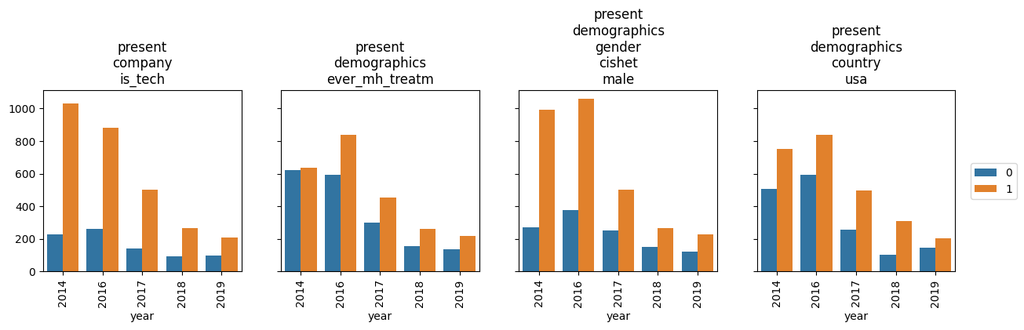

```python
fig, ax = plt.subplots(1, 4, sharey=True)

fig.set_figheight(3)
fig.set_figwidth(15)

column_order = {
    "present company is_tech": ["0", "1"],
    "present demographics ever_mh_treatm": ["0", "1"],
    "present demographics gender cishet male": [0, 1],
    "present demographics country usa": [0, 1],
}

df_overview = df_answers.reset_index()

plots = [
    sns.countplot(data=df_overview, x="year", hue=col, hue_order=order, ax=ax[i])
    for i, (col, order) in enumerate(column_order.items())
]

for i, plot in enumerate(plots):
    charts.rotate_x_labels(ax[i])
    title = list(column_order.keys())[i]
    ax[i].set_title(title.replace(" ", "\n"))
    plot.set(ylabel=None)
    if i < 3:
        ax[i].get_legend().remove()
    else:
        sns.move_legend(ax[i], "center left", bbox_to_anchor=(1.05, 0.5), title=None)
```

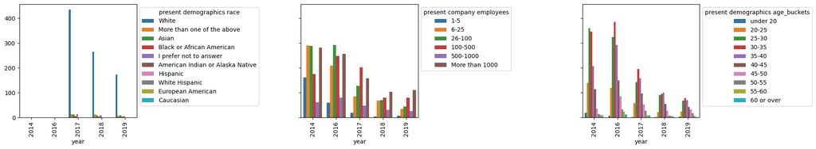

```python
fig, ax = plt.subplots(1, 6, sharey=True)

fig.set_figheight(3.5)
fig.set_figwidth(25)

column_order = {
    "present demographics race": None,
    "present company employees": None,
    "present demographics age_buckets": None,
}

df_overview = df_answers.reset_index()

plots = [
    sns.countplot(data=df_overview, x="year", hue=col, hue_order=order, ax=ax[i * 2])
    for i, (col, order) in enumerate(column_order.items())
]

for i, plot in enumerate(plots):
    charts.rotate_x_labels(ax[i * 2])
    plot.set(ylabel=None)
    sns.move_legend(ax[i * 2], "upper left", bbox_to_anchor=(1, 1))

# delete axes for odd-indexed spaces
for i in [1, 3, 5]:
    fig.delaxes(ax[i])
```

The race numbers are very interesting because they show a very strong contrast between white/non-white groups. Let's validate it by checking the original datasource.

```python
q_race = """
WITH race_white AS (
    SELECT SurveyID,
           SUM(CASE WHEN AnswerText <> '-1' THEN 1 ELSE 0 END)
               AS VALID_ANS,
           SUM(CASE WHEN AnswerText IN ('White') THEN 1 ELSE 0 END)
               AS WHITE,
           SUM(CASE WHEN AnswerText NOT IN ('White', '-1') THEN 1 ELSE 0 END)
               AS NON_WHITE
    FROM Answer
    WHERE QuestionID = 89
    GROUP BY SurveyID
)
SELECT SurveyID, WHITE, NON_WHITE, 100 * WHITE / VALID_ANS AS PCENT
FROM race_white
GROUP BY SurveyID
"""
sql_peek("Questions with sample answers", q_race)
```

Questions with sample answers

|  | SurveyID | WHITE | NON_WHITE | PCENT |
| --- | --- | --- | --- | --- |
| 0 | 2017 | 435 | 47 | 90 |
| 1 | 2018 | 265 | 37 | 87 |
| 2 | 2019 | 173 | 31 | 84 |

From this we can extract a few interesting (and unsurprising) facts:

- The year with most answers collected is 2016
  - the number of answers has been declining year-over-year since then.
- The types of companies included in the survey are mostly tech-related
- The majority of respondents have a history of mental-health treatments
- The population is moslty:
  - White
  - Male, Cisgender
  - Based in USA
- The spread across a variety of company sizes is fairly even
- The most popular age range is: 25-40

# Hypothesis

## Exploring Privilege

Question 85 reads:

> "Overall, how well do you think the tech industry supports employees with mental health issues?")

We believe that question 85 can be used to find patterns in other important indicators.

We expect to find patterns around [axes of privilege](https://en.wikipedia.org/wiki/Social_privilege) / [matrix of oppression](https://en.wikipedia.org/wiki/Matrix_of_domination)

[figure not shown]

This dataset does not cover many axis of oppression, but we will look into: race, sex, gender, and age

```python
df_answers.head(5)
```

| year | question user | past demographics mh_disorder_diag | present company anonymity | present company discussed_mh | present company employees | present company is_tech | present company mh_benefits | present company mh_leave_difficulty | present company mh_or_ph_seriously | present company resources_mh_offered | present demographics age | ... | present external_safety fam_friends | present industry support_perception | present safety company_ph | present safety mh_consequences | present safety mh_discuss_boss | present safety mh_discuss_cw | present safety mh_reveal_neg_boss | present demographics age_buckets | present demographics gender cishet male | present demographics country usa |
| --- | --- | --- | --- | --- | --- | --- | --- | --- | --- | --- | --- | --- | --- | --- | --- | --- | --- | --- | --- | --- | --- | --- |
| 2014 | 1 | NaN | Yes | NaN | 6-25 | 1 | Yes | NaN | Yes | NaN | 37 | ... | NaN | NaN | No | No | NaN | NaN | NaN | 35-40 | 0 | 1 |
|  | 2 | NaN | Don't know | NaN | More than 1000 | 0 | Don't know | NaN | Don't know | NaN | 44 | ... | NaN | NaN | No | Maybe | NaN | NaN | NaN | 40-45 | 1 | 1 |
|  | 3 | NaN | Don't know | NaN | 6-25 | 1 | No | NaN | No | NaN | 32 | ... | NaN | NaN | No | No | NaN | NaN | NaN | 30-35 | 1 | 0 |
|  | 4 | NaN | No | NaN | 26-100 | 1 | No | NaN | No | NaN | 31 | ... | NaN | NaN | Yes | Yes | NaN | NaN | NaN | 30-35 | 1 | 0 |
|  | 5 | NaN | Don't know | NaN | 100-500 | 1 | Yes | NaN | Don't know | NaN | 31 | ... | NaN | NaN | No | No | NaN | NaN | NaN | 30-35 | 1 | 1 |

5 rows × 25 columns

```python
dummies_for_columns = [
    "present industry support_perception",
    "past demographics mh_disorder_diag",
    "present company anonymity",
    "present company discussed_mh",
    "present company employees",
    "present company is_tech",
    "present company mh_benefits",
    "present company mh_leave_difficulty",
    "present company mh_or_ph_seriously",
    "present company resources_mh_offered",
    "present demographics ever_mh_treatm",
    "present demographics fam_hist_mh",
    "present demographics race",
    "present external_safety fam_friends",
    "present safety company_ph",
    "present safety mh_discuss_boss",
    "present safety mh_discuss_cw",
    "present demographics age_buckets",
    "present demographics gender cishet male",
    "present demographics country usa",
    "present safety mh_reveal_neg_boss",
    "present safety mh_consequences",
]

d_answers = pd.get_dummies(df_answers, columns=dummies_for_columns, prefix_sep="___")
d_answers = d_answers.drop(
    columns=[
        "present demographics age",
        "present demographics country",
        "present demographics gender",
    ]
)
d_answers.head(5)
```

| year | user | present industry support_perception___1 | present industry support_perception___2 | present industry support_perception___3 | present industry support_perception___4 | present industry support_perception___5 | past demographics mh_disorder_diag___No | past demographics mh_disorder_diag___Yes | present company anonymity___Don't know | present company anonymity___I don't know | present company anonymity___No | ... | present demographics gender cishet male___0 | present demographics gender cishet male___1 | present demographics country usa___0 | present demographics country usa___1 | present safety mh_reveal_neg_boss___Maybe | present safety mh_reveal_neg_boss___No | present safety mh_reveal_neg_boss___Yes | present safety mh_consequences___Maybe | present safety mh_consequences___No | present safety mh_consequences___Yes |
| --- | --- | --- | --- | --- | --- | --- | --- | --- | --- | --- | --- | --- | --- | --- | --- | --- | --- | --- | --- | --- | --- | --- |
| 2014 | 1 | 0 | 0 | 0 | 0 | 0 | 0 | 0 | 0 | 0 | 0 | ... | 1 | 0 | 0 | 1 | 0 | 0 | 0 | 0 | 1 | 0 |
|  | 2 | 0 | 0 | 0 | 0 | 0 | 0 | 0 | 1 | 0 | 0 | ... | 0 | 1 | 0 | 1 | 0 | 0 | 0 | 1 | 0 | 0 |
|  | 3 | 0 | 0 | 0 | 0 | 0 | 0 | 0 | 1 | 0 | 0 | ... | 0 | 1 | 1 | 0 | 0 | 0 | 0 | 0 | 1 | 0 |
|  | 4 | 0 | 0 | 0 | 0 | 0 | 0 | 0 | 0 | 0 | 1 | ... | 0 | 1 | 1 | 0 | 0 | 0 | 0 | 0 | 0 | 1 |
|  | 5 | 0 | 0 | 0 | 0 | 0 | 0 | 0 | 1 | 0 | 0 | ... | 0 | 1 | 0 | 1 | 0 | 0 | 0 | 0 | 1 | 0 |

5 rows × 91 columns

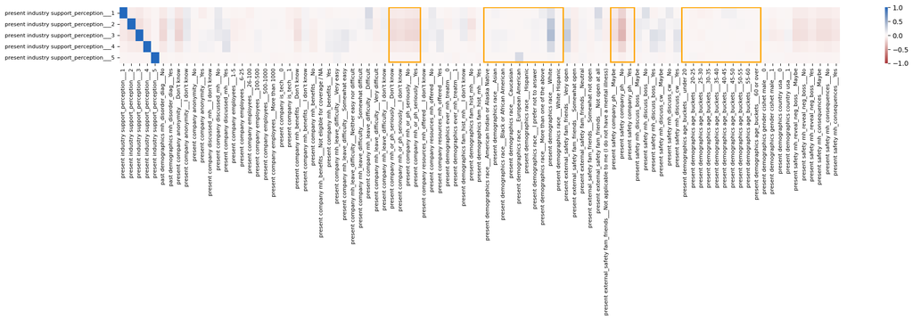

```python
perception_correlation = d_answers.corr()[
    [
        "present industry support_perception___1",
        "present industry support_perception___2",
        "present industry support_perception___3",
        "present industry support_perception___4",
        "present industry support_perception___5",
    ]
]

plt.figure(figsize=(24, 1.5))

h = sns.heatmap(perception_correlation.T, cmap="vlag_r", vmin=-1, vmax=1)

charts.sns_set_ticks_font_size(h, 8)


charts.rect(h, (34, 0), 4, 4.9)  # mh vs ph
charts.rect(h, (46, 0), 10, 4.9)  # race
charts.rect(h, (62, 0), 3, 4.9)  # present safety
charts.rect(h, (71, 0), 10, 4.9)  # age
```

Well.. this looks pretty bleak... The only interesting (non-zero-correlation) spots seem to be around:

- perceptions around psychological safety in the current company
- demographics-race

We can zoom in on these "lukewarm" areas (marked in orange) to see the scores in more detail

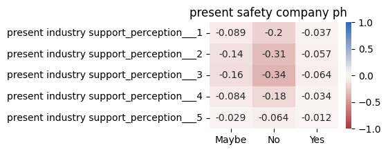

```python
mh_utils.heatmap_correlation_for(
    perception_correlation, "present safety company_ph___", (3, 2)
)
```

There is a small negative correlation between:

- people who believe that their current company is not a safe environment when disclosing/sharing physical health
- people who voted "3/5" on industry outlook.

It is unclear what is causing this, but further research should be done to understand if people are voting 3 due to lack of safety, to not "make themselves visible" and attract trouble

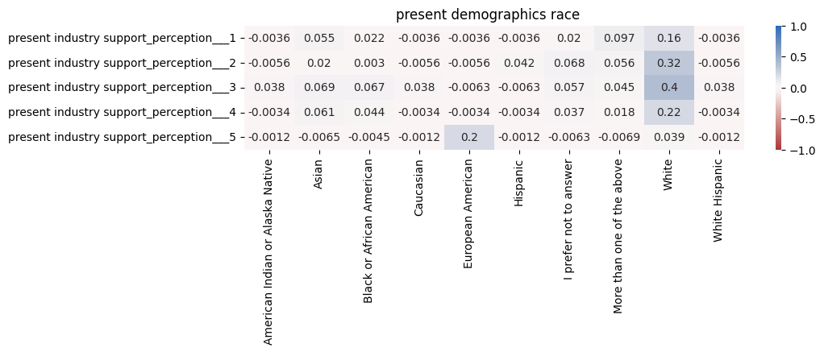

```python
mh_utils.heatmap_correlation_for(
    perception_correlation, "present demographics race___", (10, 2)
)
```

There is a mild correlation around White people answering that their perception of support in the industry is "3 out of 5/not terrible, not great". It's unclear what is driving this, is it that the question was mandatory (not optional) and they did not want to skew the results one way or the other? is it unawareness of their privilege? is it that they have never had to consider this?

This would be worth researching more. maybe in future years we could make this questio optional to see how many of those "3 out of 5" are converted to "no answer".

It would help us distinguish between people actively sharing with us their perception, vs people who felt forced to vote.

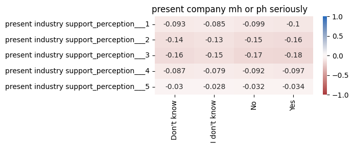

```python
mh_utils.heatmap_correlation_for(
    perception_correlation, "present company mh_or_ph_seriously___"
)
```

No clear patterns emerge

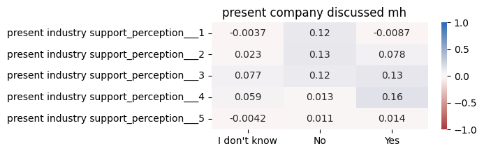

```python
mh_utils.heatmap_correlation_for(
    perception_correlation, "present company discussed_mh___"
)
```

Nothing obvious pops up

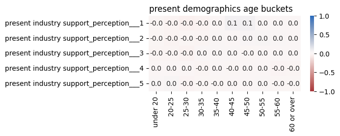

```python
mh_utils.heatmap_correlation_for(
    perception_correlation, "present demographics age_buckets___", fmt=".1f"
)
```

Looking at age, we see no correlation across any group.

This pattern will reocurr across all other studies as well.

## Exploring Diagnostics

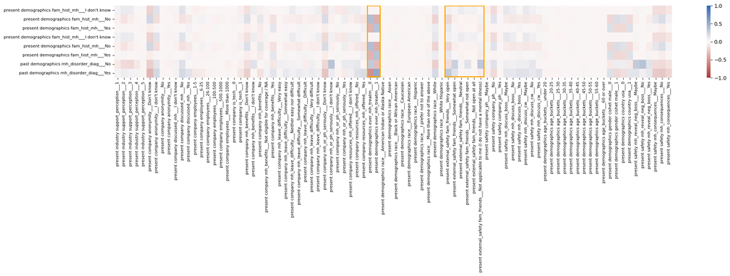

```python
diag_cols = [
    "present demographics fam_hist_mh___I don't know",
    "present demographics fam_hist_mh___No",
    "present demographics fam_hist_mh___Yes",
    "present demographics fam_hist_mh___I don't know",
    "present demographics fam_hist_mh___No",
    "present demographics fam_hist_mh___Yes",
    "past demographics mh_disorder_diag___No",
    "past demographics mh_disorder_diag___Yes",
]
diagnostics_correlation = d_answers.corr()[diag_cols]

diagnostics_correlation = diagnostics_correlation.drop(index=diag_cols)

plt.figure(figsize=(24, 2.5))

h = sns.heatmap(diagnostics_correlation.T, cmap="vlag_r", vmin=-1, vmax=1)

charts.sns_set_ticks_font_size(h, 8)

charts.rect(h, (39, 0), 2, 7.9)  # ever mh treat.
charts.rect(h, (51, 0), 6, 7.9)  # fam & friends
```

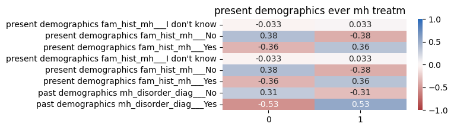

```python
mh_utils.heatmap_correlation_for(
    diagnostics_correlation, "present demographics ever_mh_treatm___"
)
```

We see a notable (and somewhat obvious) correlation between:

- people who have ever **sought treatment** for a mental health disorder from a mental health professional, and
- people who have ever **been diagnosed** with a mental health disorder.

As well as a weaker correlation around:

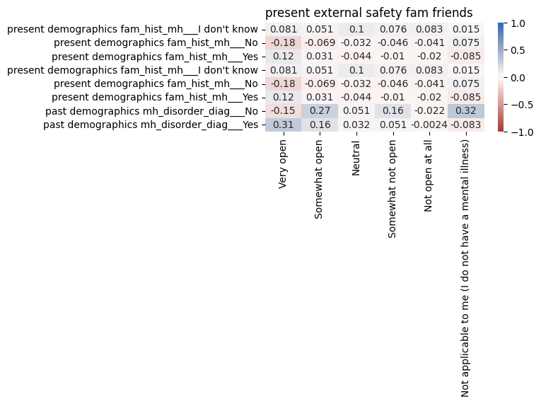

```python
mh_utils.heatmap_correlation_for(
    diagnostics_correlation, "present external_safety fam_friends___"
)
```

We can see a mild correlation between:

- people who have been diagnosed with a mental health disorder, and
- people who are open/very open to about it to family and friends.

## Exploring Safety

Next, let's look into Psychological Safety in the workplace:

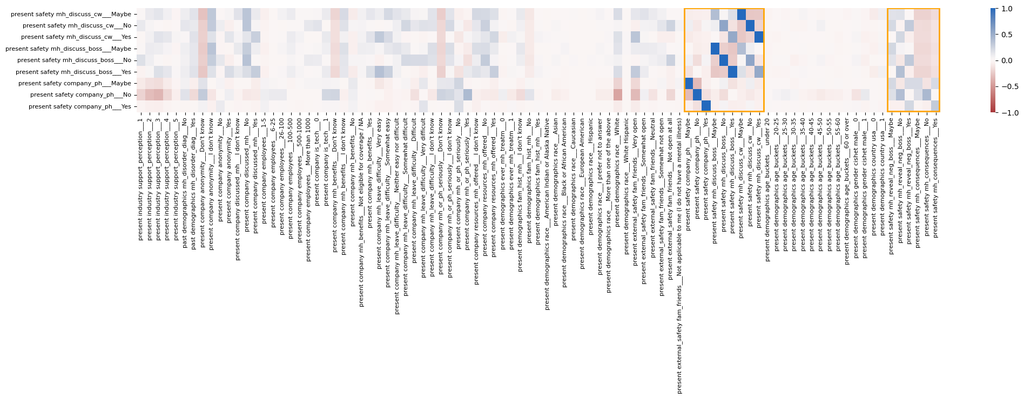

```python
safety_cols = [
    "present safety mh_discuss_cw___Maybe",
    "present safety mh_discuss_cw___No",
    "present safety mh_discuss_cw___Yes",
    "present safety mh_discuss_boss___Maybe",
    "present safety mh_discuss_boss___No",
    "present safety mh_discuss_boss___Yes",
    "present safety company_ph___Maybe",
    "present safety company_ph___No",
    "present safety company_ph___Yes",
]
diagnostics_correlation = d_answers.corr()[safety_cols]

diagnostics_correlation = diagnostics_correlation

plt.figure(figsize=(24, 2.5))

h = sns.heatmap(diagnostics_correlation.T, cmap="vlag_r", vmin=-1, vmax=1)

charts.sns_set_ticks_font_size(h, 8)

charts.rect(h, (62, 0), 9, 8.9)
charts.rect(h, (85, 0), 5.9, 8.9)
```

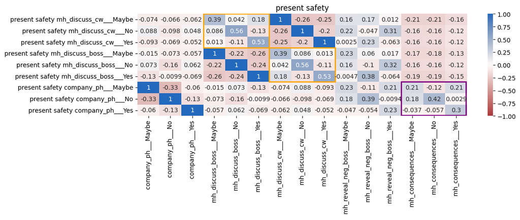

```python
c = mh_utils.heatmap_correlation_for(diagnostics_correlation, "present safety", (12, 3))

charts.rect(c, (3, 0), 3, 3)
charts.rect(c, (6, 3), 3, 3)
charts.rect(c, (12, 6), 2.95, 2.95, "purple")
```

Ignoring the (three "1 diagonals"), we can see some general correlation across all these categories:

There are some interrelation around various areas:

- safety when talking to coworkers and to their direct supervisors **(orange highlights)**
- There are some interesting insights around consequences in the workplace **(purple highlights)**

Even more notably, we want to highlight that the correlation across people who believe there will be no consequences (0.42) is much stronger than between people who think that there will be consequences (0.3) or that maybe there will be consequences (0.2), highlighting genuine gaps around safety.

This reinforces the importance around how asking the right questions, in the right way, helps highlight problems that might be hiding.

Since we cannot identify companies/corporations from this analysis, it's impossible to publicly identify/reach out to them so they are aware of these patterns.

# Conclusions

This analysis pertains to the **anth7310/mental-health-in-the-tech-industry** dataset that can be found on kaggle.

## Dataset

It contains data around mental health in the IT industry, as collected on various yearly surveys (2014 and 2016-2019),

The dataset contains an over-representation of respondents from these demographic groups:

- white, male
- based or working in the US
- between 25-40 years old

across a variety of companies (from solo/small businesses to large corporations)

This might not be a bias in the sampling strategy, but a reflection of the IT field in those spaces.

## Revisiting our initial Expectations

Let's review the list of expectations/theories we started with and assess whether they can be rejected or they warrant further investigation.

This is the original list we had:

### Privilege

The dataset includes various dimensions around privilege:

- race
- gender
- age

#### Age

While we see that the majority of population spread between 25 and 40, we cannot find any evidence or correlation across any age group when it comes to mental health support within their company or the entire industry

#### Gender

In the male/non-male analysis, we see a large proportion of self-identified male population.

While we do not see any strong correlations across data with regards to gender, it's important to keep in mind this over-representation in case it skews results for everyone else, if we were to look at overall averages.

#### Race

If the male/non-male analysis shows an over-representation, the race breakdown (both, across years, and also in general terms) shows a total eclipse of white people over everyone else, with ratios between 84-90% depending on the year.

Non-white respondents include 9 other groups and their second most common answer is "I prefer not to answer", which raises questions around psychological safety of the responders, maybe worrying about being outed if their answers were to be available to their employers.

### Diagnostics

- People who sought treatment are correlated with people diagnosed. Since this is almost a requirement, the interesting thing with this dataset might be in the negative space, more than the correlation itself.

### Pyschological Safety

When exploring people who got a diagnosis vs none, we saw that people who did are generally more open to sharing their journey with families and friends.

The meta analysis also included hypothesis around safety in the workplace.

The lack of company information makes it difficult to detect which companies might be suffering from a lack of psychological safety among their staff (intentional or not), and means to address it/notify them.

## Executive Summary

Our company is considering implementing a survey like this one across IT/tech employees.

Here are some things we could do to get more useful insights.

1. Being aware of industry-wide trends and biases:
   - so we can craft questions that include everyone
2. Assessing Psychological Safety so it can be acted/improved.
   - Some questions might benefit from being optional, or allowing "I don't know" answers.

### Assessing Safety

In the dataset, we can see a few examples of questions defaulting to "middle score" (3 stars out of 5) when:

- The questions is mandatory
- "I don't know" options are not available,
- and the topic might be sensitive, or there is a fear of retaliation (low psych safety)

Perhaps the more interesting insights for individual companies might come from how many people respond with a non-answer (i don't know, blank, etc...) to identify which departments have lower safety scores.